# **Data Cleaning and Analysis**

### **Overview**

Through this *Jupyter Notebook*, we are going to analyse the **financial datasets** prepared in *Excel*, with all the *data* imported from the *Bloomberg Terminal*.

The *Excel Workbook* is located in the *data* folder of the main project with the name: *Bloomberg_Raw_Data.xlsx*

Before having a look to the *results* coming from cleaning and analysis result, it is important to refer the scripts provided through the folder *src* of the *main project*, all the *Classes* and *Methods* defined there help the user to have a clear view of the *results*.

In the *aforementioned* scripts, also a *Yahoo Finance* *Datasets cleaner* is provided.

Due to the *scant* amount of the **data**, *Bloomberg Terminal* source is currently preferred.

### **Bloomberg Source**

With the following **code blocks**, three different *financial instruments* will be presented. In particular:

- **SPX**
- **NDX**
- **MSCI US Equity**

As could be seen, from the first block, this **Jupyer Notebook** is actually able to have a look to the entire **Excel Workbook**, providing to the user different choices and decide which financial asset to analyse.

In this specific **scenario**, we are going to analyse, for each of the **financial instruments** before mentioned: different statistical indicators and plots.

These would be needed to extract *eventual* and *significant* information for the **Portfolio Optimization Model**, which is the objective of the entire project.

With the following **code blocks**, three different *financial instruments* will be presented.  
In particular:

- **SPX**
- **NDX**
- **MSCI US Equity**

As could be seen, from the first block, this **Jupyer Notebook** is actually able to have a look to the entire **Excel Workbook**, providing to the user different choices and decide which financial asset to analyse.  
In this specific **scenario**, we are going to analyse, for each of the **financial instruments** before mentioned: different statistical indicators and plots.  
These would be needed to extract *eventual* and *significant* information for the **Portfolio Optimization Model**, which is the objective of the entire project.

### **Implementation**

We are now defining the **Data Source**

```python
import warnings

warnings.filterwarnings("ignore")

source_dir: str = "../data/"
filename_bloomberg_raw_data_source: str = "Bloomberg_Raw_Data.xlsx"
path_bloomberg_raw_data_source: str = source_dir + filename_bloomberg_raw_data_source
```

Have a look to the structure of the **Excel Workbook**

```python
import pandas as pd

excel_file_bloomberg_data_source: pd.ExcelFile = pd.ExcelFile(
    path_bloomberg_raw_data_source
)
sheet_names: list = excel_file_bloomberg_data_source.sheet_names

print("These are the names of each worksheet in the Excel Workbook\n")

for sheet_name in sheet_names:
    print(f"Financial Instrument: {sheet_name}")
```

```
These are the names of each worksheet in the Excel Workbook

Financial Instrument: SPX Index
Financial Instrument: NDX Index
Financial Instrument: UKX Index
Financial Instrument: DAX Index
Financial Instrument: NKY Index
Financial Instrument: NIFTY Index
Financial Instrument: MSCI US Equity
Financial Instrument: MXWO Index
Financial Instrument: MXEF Index
Financial Instrument: MXWD Index
Financial Instrument: MXEU Index
```

We now set the *asset* we want to analyse, **Start Date** and **End Date**

```python
from datetime import date

asset: str = "SPX Index"

start_date: date = date(2020, 1, 1)
end_date: date = date(2023, 1, 1)

from portfolio.datasets.bloomberg.asset import Asset as BAsset

bloomberg_asset = BAsset(
    path_bloomberg_raw_data_source,
    sheet_name=asset,
    start_date=start_date,
    end_date=end_date,
)
```

Let's now obtain some more specific *statistical information* on the following **financial product**

```python
from portfolio.benchmark.performance import PortfolioPerformer


performance = PortfolioPerformer(bloomberg_asset.returns())

print(
    f"""
Financial Asset: {asset}

Summary Statistics on Returns

Mean\t\t\t{performance.mean()}
Mode\t\t\t{performance.mode()[0]}

Min\t\t\t{performance.min()}
First Quartile\t\t{performance.first_quartile()}
Median\t\t\t{performance.median()}
Third Quartile\t\t{performance.third_quartile()}
Max\t\t\t{performance.max()}

Var\t\t\t{performance.variance()}
StdDev\t\t\t{performance.standard_deviation()}
UpsideStdDev\t\t{performance.upside_standard_deviation()}
DownsideStdDev\t\t{performance.downside_standard_deviation()}

Sharpe Ratio\t\t{performance.sharpe_ratio()}
Sortino Ratio\t\t{performance.sortino_ratio()}
Skewness\t\t{performance.skewness()}
Kurtosis\t\t{performance.kurtosis()}

Start Date\t\t{start_date}
End Date\t\t{end_date}
Activity Time\t\t{end_date - start_date}\n\n
"""
)
```

```
Financial Asset: SPX Index

Summary Statistics on Returns

Mean			0.00034687716502949554
Mode			-0.11984050283657066

Min			-0.11984050283657066
First Quartile		-0.006735439591645465
Median			0.0008812208263346832
Third Quartile		0.008207144339747452
Max			0.09382765710199337

Var			0.0002569649450269998
StdDev			0.016030126170027477
UpsideStdDev		0.011179842381100773
DownsideStdDev		0.012899159923030706

Sharpe Ratio		0.02163907890370029
Sortino Ratio		0.026891453947335466
Skewness		-0.451964500981155
Kurtosis		10.02760192853926

Start Date		2020-01-01
End Date		2023-01-01
Activity Time		1096 days, 0:00:00
```

Let's now analyse the **plots**

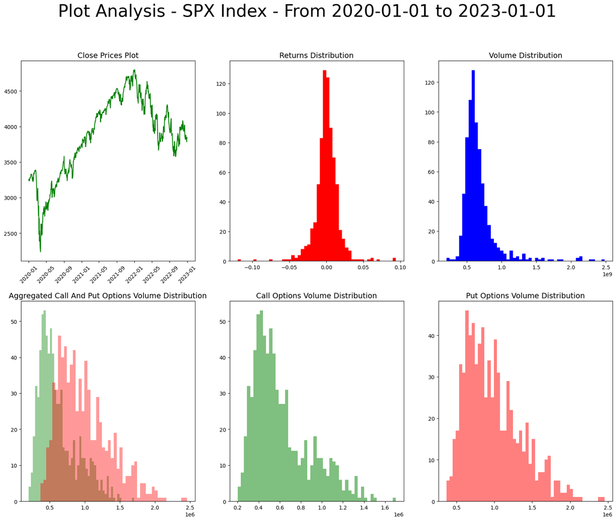

```python
import matplotlib.pyplot as plt

fig, axs = plt.subplots(nrows=2, ncols=3, figsize=(20, 15))
fig.suptitle(f"Plot Analysis - {asset} - From {start_date} to {end_date}", fontsize=32)

axs[0, 0].set_title("Close Prices Plot", fontsize=14)
axs[0, 0].plot(bloomberg_asset.dates(), bloomberg_asset.close_prices(), color="green")
axs[0, 0].tick_params(axis="x", labelrotation=45)
axs[0, 1].set_title("Returns Distribution", fontsize=14)
axs[0, 1].hist(bloomberg_asset.returns(), bins=50, color="red")
axs[0, 2].set_title("Volume Distribution", fontsize=14)
axs[0, 2].hist(bloomberg_asset.volumes(), bins=50, color="blue")

axs[1, 0].set_title("Aggregated Call And Put Options Volume Distribution", fontsize=14)
axs[1, 0].hist(bloomberg_asset.call_options_volume(), bins=50, color="green", alpha=0.4)
axs[1, 0].hist(bloomberg_asset.put_options_volume(), bins=50, color="red", alpha=0.4)
axs[1, 1].set_title("Call Options Volume Distribution", fontsize=14)
axs[1, 1].hist(bloomberg_asset.call_options_volume(), bins=50, color="green", alpha=0.5)
axs[1, 2].set_title("Put Options Volume Distribution", fontsize=14)
axs[1, 2].hist(bloomberg_asset.put_options_volume(), bins=50, color="red", alpha=0.5)
```

We iterate the same previous process for the **Nasdaq-100 Index**

```python
from datetime import date

asset: str = "NDX Index"

start_date: date = date(2020, 1, 1)
end_date: date = date(2023, 1, 1)

from portfolio.datasets.bloomberg.asset import Asset as BAsset

bloomberg_asset = BAsset(
    path_bloomberg_raw_data_source,
    sheet_name=asset,
    start_date=start_date,
    end_date=end_date,
)
```

```python
from portfolio.benchmark.performance import PortfolioPerformer


performance = PortfolioPerformer(bloomberg_asset.returns())

print(
    f"""
Financial Asset: {asset}

Summary Statistics on Returns

Mean\t\t\t{performance.mean()}
Mode\t\t\t{performance.mode()[0]}

Min\t\t\t{performance.min()}
First Quartile\t\t{performance.first_quartile()}
Median\t\t\t{performance.median()}
Third Quartile\t\t{performance.third_quartile()}
Max\t\t\t{performance.max()}

Var\t\t\t{performance.variance()}
StdDev\t\t\t{performance.standard_deviation()}
UpsideStdDev\t\t{performance.upside_standard_deviation()}
DownsideStdDev\t\t{performance.downside_standard_deviation()}

Sharpe Ratio\t\t{performance.sharpe_ratio()}
Sortino Ratio\t\t{performance.sortino_ratio()}
Skewness\t\t{performance.skewness()}
Kurtosis\t\t{performance.kurtosis()}

Start Date\t\t{start_date}
End Date\t\t{end_date}
Activity Time\t\t{end_date - start_date}\n\n
"""
)
```

```
Financial Asset: NDX Index

Summary Statistics on Returns

Mean			0.0004587182274350212
Mode			-0.12193224485507659

Min			-0.12193224485507659
First Quartile		-0.008856228292129564
Median			0.0014586938017795426
Third Quartile		0.010673432365108648
Max			0.10072208875702993

Var			0.0003607836799759805
StdDev			0.018994306514742265
UpsideStdDev		0.012458471682318237
DownsideStdDev		0.014272067441032118

Sharpe Ratio		0.024150301411583048
Sortino Ratio		0.03214097952733945
Skewness		-0.2946264444811007
Kurtosis		4.771559088299471

Start Date		2020-01-01
End Date		2023-01-01
Activity Time		1096 days, 0:00:00
```

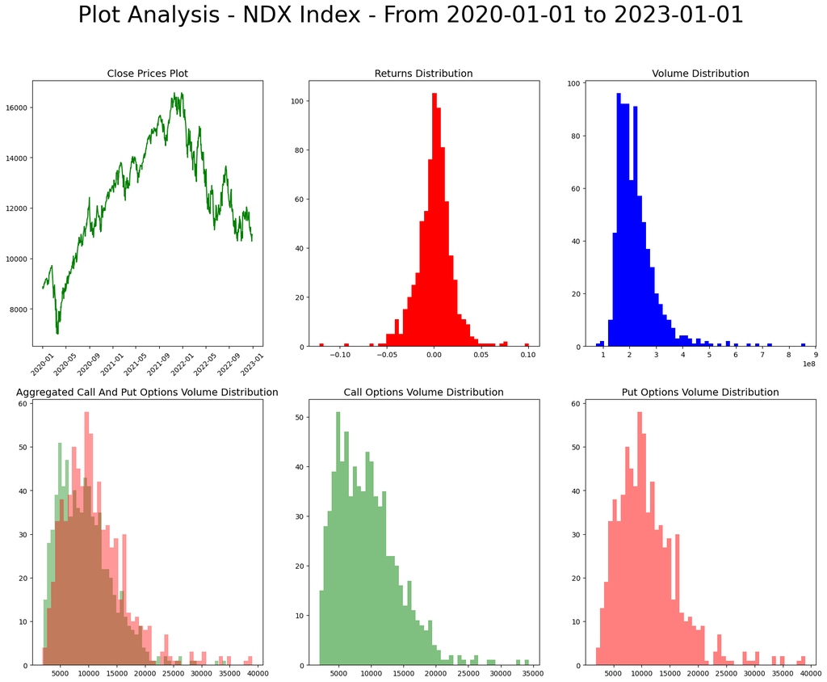

```python
import matplotlib.pyplot as plt

fig, axs = plt.subplots(nrows=2, ncols=3, figsize=(20, 15))
fig.suptitle(f"Plot Analysis - {asset} - From {start_date} to {end_date}", fontsize=32)

axs[0, 0].set_title("Close Prices Plot", fontsize=14)
axs[0, 0].plot(bloomberg_asset.dates(), bloomberg_asset.close_prices(), color="green")
axs[0, 0].tick_params(axis="x", labelrotation=45)
axs[0, 1].set_title("Returns Distribution", fontsize=14)
axs[0, 1].hist(bloomberg_asset.returns(), bins=50, color="red")
axs[0, 2].set_title("Volume Distribution", fontsize=14)
axs[0, 2].hist(bloomberg_asset.volumes(), bins=50, color="blue")

axs[1, 0].set_title("Aggregated Call And Put Options Volume Distribution", fontsize=14)
axs[1, 0].hist(bloomberg_asset.call_options_volume(), bins=50, color="green", alpha=0.4)
axs[1, 0].hist(bloomberg_asset.put_options_volume(), bins=50, color="red", alpha=0.4)
axs[1, 1].set_title("Call Options Volume Distribution", fontsize=14)
axs[1, 1].hist(bloomberg_asset.call_options_volume(), bins=50, color="green", alpha=0.5)
axs[1, 2].set_title("Put Options Volume Distribution", fontsize=14)
axs[1, 2].hist(bloomberg_asset.put_options_volume(), bins=50, color="red", alpha=0.5)
```

And for the **MSCI US Equity Index**

```python
from datetime import date

asset: str = "MSCI US Equity"

start_date: date = date(2020, 1, 1)
end_date: date = date(2023, 1, 1)

from portfolio.datasets.bloomberg.asset import Asset as BAsset

bloomberg_asset = BAsset(
    path_bloomberg_raw_data_source,
    sheet_name=asset,
    start_date=start_date,
    end_date=end_date,
)
```

```python
from portfolio.benchmark.performance import PortfolioPerformer


performance = PortfolioPerformer(bloomberg_asset.returns())

print(
    f"""
Financial Asset: {asset}

Summary Statistics on Returns

Mean\t\t\t{performance.mean()}
Mode\t\t\t{performance.mode()[0]}

Min\t\t\t{performance.min()}
First Quartile\t\t{performance.first_quartile()}
Median\t\t\t{performance.median()}
Third Quartile\t\t{performance.third_quartile()}
Max\t\t\t{performance.max()}

Var\t\t\t{performance.variance()}
StdDev\t\t\t{performance.standard_deviation()}
UpsideStdDev\t\t{performance.upside_standard_deviation()}
DownsideStdDev\t\t{performance.downside_standard_deviation()}

Sharpe Ratio\t\t{performance.sharpe_ratio()}
Sortino Ratio\t\t{performance.sortino_ratio()}
Skewness\t\t{performance.skewness()}
Kurtosis\t\t{performance.kurtosis()}

Start Date\t\t{start_date}
End Date\t\t{end_date}
Activity Time\t\t{end_date - start_date}\n\n
"""
)
```

```
Financial Asset: MSCI US Equity

Summary Statistics on Returns

Mean			0.0010719376068628276
Mode			-0.13055751587861675

Min			-0.13055751587861675
First Quartile		-0.011911087474231585
Median			0.001549031855090588
Third Quartile		0.014418191993637364
Max			0.18034981645432957

Var			0.0006654730713687849
StdDev			0.02579676474616119
UpsideStdDev		0.018549172458269203
DownsideStdDev		0.017772313892842624

Sharpe Ratio		0.04155317992045271
Sortino Ratio		0.06031502781945152
Skewness		0.28939675238247703
Kurtosis		6.011385204368063

Start Date		2020-01-01
End Date		2023-01-01
Activity Time		1096 days, 0:00:00
```

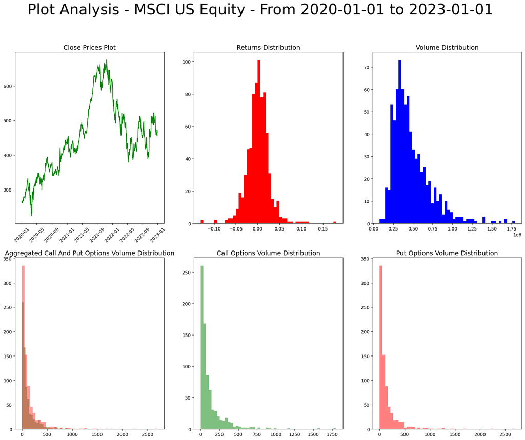

```python
import matplotlib.pyplot as plt

fig, axs = plt.subplots(nrows=2, ncols=3, figsize=(20, 15))
fig.suptitle(f"Plot Analysis - {asset} - From {start_date} to {end_date}", fontsize=32)

axs[0, 0].set_title("Close Prices Plot", fontsize=14)
axs[0, 0].plot(bloomberg_asset.dates(), bloomberg_asset.close_prices(), color="green")
axs[0, 0].tick_params(axis="x", labelrotation=45)
axs[0, 1].set_title("Returns Distribution", fontsize=14)
axs[0, 1].hist(bloomberg_asset.returns(), bins=50, color="red")
axs[0, 2].set_title("Volume Distribution", fontsize=14)
axs[0, 2].hist(bloomberg_asset.volumes(), bins=50, color="blue")

axs[1, 0].set_title("Aggregated Call And Put Options Volume Distribution", fontsize=14)
axs[1, 0].hist(bloomberg_asset.call_options_volume(), bins=50, color="green", alpha=0.4)
axs[1, 0].hist(bloomberg_asset.put_options_volume(), bins=50, color="red", alpha=0.4)
axs[1, 1].set_title("Call Options Volume Distribution", fontsize=14)
axs[1, 1].hist(bloomberg_asset.call_options_volume(), bins=50, color="green", alpha=0.5)
axs[1, 2].set_title("Put Options Volume Distribution", fontsize=14)
axs[1, 2].hist(bloomberg_asset.put_options_volume(), bins=50, color="red", alpha=0.5)
```

### Conclusion

The **deep reinforcement learning field** applied to *finance* requires us to highlight the *statistical* and *financial properties* of a *financial asset*.

By understanding these *properties*, such as *volatility* and *distributional structures*, these type of **algorithms** can effectively **navigate** and, potentially **exploit**, *complex market dynamics* (This is what we hope).

Moreover, incorporating **empirical stylized facts**, such as *fat tails* in return distributions or *volatility clustering*, enhances the *robustness* and *realism* of these financial models.